```python
import numpy as np
import pandas as pd
import sklearn.linear_model as skl_lm
import matplotlib.pyplot as plt

# Just to get nicer plots
from IPython.display import set_matplotlib_formats
# set_matplotlib_formats('svg') # Output as svg. Else you can try png
from IPython.core.pylabtools import figsize
figsize(10, 6) # Width and hight
```

# 2.1 Problem 1.1 using matrix multiplications

Implement the linear regression problems from Exercises 1.1(a), (b), (c), (d) and (e) in Python using matrix multiplications. A matrix $$\textbf{X} = \begin{bmatrix} 1 & 2 \\ 1 & 3 \\ \end{bmatrix} $$ can be constructed with numpy as `X=np.array([[1, 2], [1, 3]])` (Make sure that `numpy` has been imported. Here it is imported as `np`). The commands for matrix multiplication and transpose in `numpy` are `@` or `np.matmul` and `.T` or `np.transpose()` respectively. A system of linear equations $\textbf{A}x=\textbf{b}$ can be solved using `np.linalg.solve(A,b)`. A $k \times k$ unit matrix can be constructed with `np.eye(k)`.

## (a)

```python
# Construct the data matrix
X = np.array([[1, 2], [1, 3]])
y = np.array([-1, 1])

# Solve the normal equations
theta = np.linalg.solve(X.T@X, X.T@y)

# Print the solution
print(f"\u0302\u03b8 = {theta}")

# Compute prediction for x = 4
yhat = theta@np.array([1,4])

# Print the prediction
print(f"\u0302y = {yhat}")
```

```
̂θ = [-5.  2.]
̂y = 2.9999999999999982
```

## (b)

```python
# Construct the data matrices
X = np.array([[1, 2], [1, 3], [1, 4]])
y = np.array([-1, 1 ,2])

# Compute the solution using the normal equation
theta = np.linalg.solve(X.T@X,X.T@y)

# Print the solution
print(f"\u0302\u03b8 = {theta}")

# Compute prediction for x = 5
yhat = theta@np.array([1,5])

# Print the prediction
print(f"\u0302y = {yhat}")
```

```
̂θ = [-3.83333333  1.5       ]
̂y = 3.6666666666666696
```

## (c)

```python
# Consctruct the data matrices
# Reshape the array to 2-dim so we can use np.linalg.solve()
X = np.array([2, 3, 4]).reshape(-1, 1)
y = np.array([-1, 1, 2])

# Compute the solution
theta = np.linalg.solve(X.T@X,X.T@y)

# Print the solution
print(f"\u0302\u03b8 = {theta}")

# Compute prediction for x = 5
yhat = theta@np.array([5])

# Print the prediction
print(f"\u0302y = {yhat}")
```

```
̂θ = [0.31034483]
̂y = 1.5517241379310345
```

## (d)

```python
# Use the solution to the Ridge Regression problem
# Construct the data matrices
X = np.array([[1, 2], [1, 3], [1, 4]])
y = np.array([-1, 1, 2])
lambd = 1

# Compute the solution
theta = np.linalg.solve(X.T@X+np.eye(2),X.T@y)

# Print the solution
print(f"\u0302\u03b8 = {theta}")

# Compute prediction for x = 5
yhat = theta@np.array([1,5])

# Print the prediction
print(f"\u0302y = {yhat}")
```

```
̂θ = [-0.53846154  0.46153846]
̂y = 1.7692307692307696
```

## (e)

```python
# Construct the data matrices
X = np.array([[1, 2], [1, 3], [1, 4]])
Y = np.array([[-1, 0], [1, 2], [2, -1]])

# Compute the solution
theta = np.linalg.solve(X.T@X,X.T@Y)

# Print the solution
print(f"\u0302\u03b8 =\n{theta}")
```

```
̂θ =
[[-3.83333333  1.83333333]
 [ 1.5        -0.5       ]]
```

# 2.2 Problem 1.1 using the linear_model.LinearRegression() command

Implement the linear regression problem from Exercises 1.1(b) and (c) using the command `LinearRegression()` from `sklearn.linear_model`.

## (b)

```
The coeficient beta_1 for X is :  [1.5]
The offset beta_0 is:  -3.8333333333333326
```

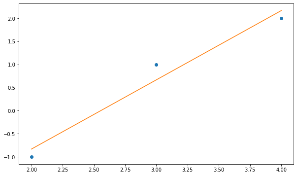

```python
X = np.array([2, 3, 4]).reshape(-1, 1)
y = np.array([-1, 1 , 2])

# Learn the model using the skl_lm() command
model = skl_lm.LinearRegression()
model.fit(X, y)

# Print the solution
print('The coeficient beta_1 for X is : ', model.coef_)
print('The offset beta_0 is: ', model.intercept_)

# Plot the data and the model
plt.plot(X, y, 'o')
prediction = model.predict(X)
plt.plot(X, prediction);
```

## (c)

```
The coeficient for X is :  [0.31034483]
The offset is:  0.0
```

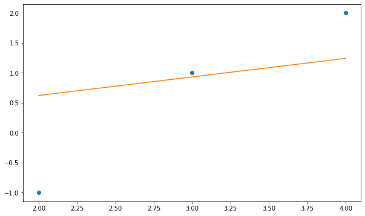

```python
# Learn the model using the skl_lm() command without intercept
model = skl_lm.LinearRegression(fit_intercept=False)
model.fit(X, y)

# Print the solution
print('The coeficient for X is : ', model.coef_)
print('The offset is: ', model.intercept_)

# Plot the data and the model
plt.plot(X, y, 'o')
prediction = model.predict(X)
plt.plot(X, prediction);
```

# 2.3 The Auto data set

## (a)

Load the dataset `'Data/Auto.csv'`. Familiarize yourself with the dataset using `Auto.info()`. The dataset:

**Description**: Gas mileage, horsepower, and other information for 392 vehicles.  
**Format**: A data frame with 392 observations on the following 9 variables.

- `mpg`: miles per gallon
- `cylinders`: Number of cylinders between 4 and 8
- `displacement`: Engine displacement (cu. inches)
- `horsepower`: Engine horsepower
- `weight`: Vehicle weight (lbs.)
- `acceleration`: Time to accelerate from 0 to 60 mph (sec.)
- `year`: Model year (modulo 100)
- `origin`: Origin of car (1. American, 2. European, 3. Japanese)
- `name`: Vehicle name  
  *The orginal data contained 408 observations but 16 observations with missing values were removed.*

```python
# Set seed to get reproducible results
np.random.seed(1)

# a) load library and familiarize with the data
# The null values are '?' in the dataset. `na_values="?"` recognize the null values.
# There are null values that will mess up the computation. Easier to drop them by `dropna()`.
Auto = pd.read_csv('Data/Auto.csv', na_values='?').dropna()
print(Auto.shape)
Auto.info()
```

```
(392, 9)
<class 'pandas.core.frame.DataFrame'>
Int64Index: 392 entries, 0 to 396
Data columns (total 9 columns):
mpg             392 non-null float64
cylinders       392 non-null int64
displacement    392 non-null float64
horsepower      392 non-null float64
weight          392 non-null int64
acceleration    392 non-null float64
year            392 non-null int64
origin          392 non-null int64
name            392 non-null object
dtypes: float64(4), int64(4), object(1)
memory usage: 30.6+ KB
```

## (b)

Divide the data set randomly into two approximately equally sized subsets, `train` and `test` by generating the random indices using `np.random.choice()`.

```python
print(Auto.shape) #(No. of rows, No. of columns)
trainI = np.random.choice(Auto.shape[0], size=200, replace=False)
trainIndex = Auto.index.isin(trainI)
train = Auto.iloc[trainIndex]
test = Auto.iloc[~trainIndex]
```

```
(392, 9)
```

## (c)

Perform linear regression with `mpg` as the output and all other variables except name as input. How well (in terms of root-mean-square-error) does the model perform on test data and training data, respectively?

```python
# Igore RuntimeWarning: internal gelsd driver lwork query error. Harmless

# Linear regression
model = skl_lm.LinearRegression(fit_intercept = True)      # Add an offset
X_train = train[['cylinders', 'displacement', 'horsepower', 'weight',\
                 'acceleration', 'year', 'origin']]
Y_train = train['mpg']
model.fit(X_train, Y_train)
print(model)

# Evaluate on training data
train_predict = model.predict(X_train)
train_RMSE = np.sqrt(np.mean((train_predict - train.mpg)**2))
print('Train RMSE: %2.6f' % train_RMSE)

## Evaluate on test data
X_test = test[['cylinders', 'displacement', 'horsepower', 'weight',\
               'acceleration', 'year', 'origin']]
test_predict = model.predict(X_test)
test_RMSE = np.sqrt(np.mean((test_predict - test.mpg)**2))
print('Test RMSE: %2.6f' % test_RMSE)
```

```
LinearRegression(copy_X=True, fit_intercept=True, n_jobs=None,
         normalize=False)
Train RMSE: 3.282090
Test RMSE: 3.336977
```

## (d)

Now, consider the input variable `origin`. What do the different numbers represent? By running `Auto.origin.sample(30)` we see the 30 samples of the variable and that the input variables is quantitative. Does it really makes sense to treat it as a quantitative input? Use `np.get_dummies()` to split it into dummy variables and do the linear regression again.

```python
# Examples of the origin variable
print('Auto origin:')
print(Auto.origin.sample(30).tolist())

X_train = pd.get_dummies(train, columns=['origin'])
print('X after transformation (origin has been split in three dummy variables):')
print(X_train.head())
# Pick out the input variables
X_train = X_train[['cylinders', 'displacement', 'horsepower', 'weight',\
                   'acceleration', 'year', 'origin_1', 'origin_2', 'origin_3']]

X_test = pd.get_dummies(test, columns=['origin'])
X_test = X_test[['cylinders', 'displacement', 'horsepower', 'weight',\
                 'acceleration', 'year', 'origin_1', 'origin_2', 'origin_3']]

# look at how sci-kit learn transforms the qualitative input
print(X_train.sample(5))

# Repeat c) create and evaluate the model now using encoded categorical data
model1 = skl_lm.LinearRegression()
model1.fit(X_train, Y_train)
print(model1)

# Evaluate on training data
train_predict = model1.predict(X_train)
train_RMSE = np.sqrt(np.mean((train_predict - train.mpg)**2))
print('Train RMSE: %2.6f' % train_RMSE)

## Evaluate on test data
test_predict = model1.predict(X_test)
test_RMSE = np.sqrt(np.mean((test_predict - test.mpg)**2))
print('Test RMSE: %2.6f' % test_RMSE)
```

```
Auto origin:
[1, 1, 1, 1, 1, 2, 1, 3, 1, 2, 3, 1, 3, 2, 3, 1, 1, 1, 1, 1, 1, 1, 1, 1, 1, 1, 1, 1, 1, 3]
X after transformation (origin has been split in three dummy variables):
    mpg  cylinders  displacement  horsepower  weight  acceleration  year  \
0  18.0          8         307.0       130.0    3504          12.0    70
4  17.0          8         302.0       140.0    3449          10.5    70
5  15.0          8         429.0       198.0    4341          10.0    70
6  14.0          8         454.0       220.0    4354           9.0    70
8  14.0          8         455.0       225.0    4425          10.0    70

                        name  origin_1  origin_2  origin_3
0  chevrolet chevelle malibu         1         0         0
4                ford torino         1         0         0
5           ford galaxie 500         1         0         0
6           chevrolet impala         1         0         0
8           pontiac catalina         1         0         0
     cylinders  displacement  horsepower  weight  acceleration  year  \
98           6         250.0       100.0    3278          18.0    73
285          8         305.0       130.0    3840          15.4    79
236          4         140.0        89.0    2755          15.8    77
213          8         350.0       145.0    4055          12.0    76
373          4         140.0        92.0    2865          16.4    82

     origin_1  origin_2  origin_3
98          1         0         0
285         1         0         0
236         1         0         0
213         1         0         0
373         1         0         0
LinearRegression(copy_X=True, fit_intercept=True, n_jobs=None,
         normalize=False)
Train RMSE: 3.262970
Test RMSE: 3.310753
```

## (e)

Try obtain a better RMSE on test data by removing some inputs (explore what happens if you remove, e.g, `year`, `weight` and `acceleration`)

```python
# First write a funcion that takes the prediction model, training and test data
# and computes RMSE to simplify the process

def computeRMSE(model, X, Y):
    Y_predict = model.predict(X)
    RMSE = np.sqrt(np.mean((Y_predict - Y)**2))
    return RMSE

# The following function streamlines the procedure of testing with dropping
# different varibles. It is optional. But if you want to skip the function
# keep in mind that when you declare e.g. X=X.drop(columns=column_name),
# you are manipulating the original X
def RMSE_with_drop_col(model, X, Y, X_test, Y_test, drop_col):
    # drop_col takes a list of string or strings
    print("Results without the variable '%s':" % drop_col)
    X = X.drop(columns=drop_col)
    model.fit(X, Y)
    train_RMSE = computeRMSE(model, X, Y)
    print('Train RMSE %2.6f' % train_RMSE)

    X_test = X_test.drop(columns=drop_col)
    test_RMSE = computeRMSE(model, X_test, Y_test)
    print('Test RMSE %2.6f' % test_RMSE)
    print()

# Test output (has not been declared)
Y_test = test.mpg

# Remove weight
model2 = skl_lm.LinearRegression()
RMSE_with_drop_col(model2, X_train, Y_train, X_test, Y_test,\
                   ['weight', 'acceleration'])

# Remove year
model3 = skl_lm.LinearRegression()
RMSE_with_drop_col(model3, X_train, Y_train, X_test, Y_test, ['year'])

# Remove acceleration
model4 = skl_lm.LinearRegression()
RMSE_with_drop_col(model4, X_train, Y_train, X_test, Y_test, ['acceleration'])
```

```
Results without the variable '['weight', 'acceleration']':
Train RMSE 3.749640
Test RMSE 3.835552

Results without the variable '['year']':
Train RMSE 4.171414
Test RMSE 4.097517

Results without the variable '['acceleration']':
Train RMSE 3.264964
Test RMSE 3.312246
```

## (f)

Try to obtain a better RMSE on test data by adding some transformations of inputs, such as $log(x)$, $\sqrt{x}$, $x_1x_2$ etc.

```python
# A small function to simplify the process
def RMSE_with_cols(model, X, Y, cols):
    print("RMSE with the variables '%s':" % cols)
    X = X[cols]
    model.fit(X, Y)
    RMSE = computeRMSE(model, X, Y)
    print('RMSE %2.6f' % RMSE)

# horsepower*acceleration
print('comp = horsepower * acceleration')
model = skl_lm.LinearRegression()
X_train_copy = X_train.copy()     # A hard copy to avoid manipulating the original X
X_train_copy['comp'] = X_train_copy.horsepower * X_train_copy.acceleration
cols = ['cylinders', 'displacement','comp', 'origin_1', 'origin_2', 'origin_3']
RMSE_with_cols(model, X_train_copy, Y_train, cols)

print()

# sqrt(horsepower) and weight^2
print('sqrt(horsepower) and weight^2')
model = skl_lm.LinearRegression()
X_train_copy = X_train.copy()
X_train_copy['sqrt_horsepower'] = np.sqrt(X_train_copy.horsepower)
X_train_copy['weight_sqr'] = X_train_copy.weight**2
cols = ['cylinders', 'displacement','sqrt_horsepower', 'weight_sqr',\
        'origin_1', 'origin_2', 'origin_3']
RMSE_with_cols(model, X_train_copy, Y_train, cols)
```

```
comp = horsepower * acceleration
RMSE with the variables '['cylinders', 'displacement', 'comp', 'origin_1', 'origin_2', 'origin_3']':
RMSE 4.187345

sqrt(horsepower) and weight^2
RMSE with the variables '['cylinders', 'displacement', 'sqrt_horsepower', 'weight_sqr', 'origin_1', 'origin_2', 'origin_3']':
RMSE 4.182440
```

# 2.4 Nonlinear transformations of input variables

Start by running the following code to generate your training data

```
np.random.seed(1)
x_train = np.random.uniform(0, 10, 100)
y_train = .4 - .6 * x_train + 3. * np.sin(x_train - 1.2) + np.random.normal(0, 0.1, 100)
```

```python
np.random.seed(1)
x_train = np.random.uniform(0, 10, 100)
y_train = .4 - .6 * x_train + 3. * np.sin(x_train - 1.2) + \
np.random.normal(0, 0.1, 100)
```

## (a)

Plot the training output y_train versus the training input x_train.

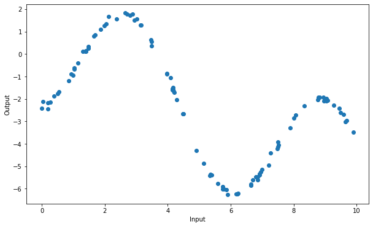

```python
# a) Plot
plt.plot(x_train, y_train, 'o')
plt.xlabel('Input')
plt.ylabel('Output')
```

## (b)

Learn a model on the form $$y= a + bx + c sin(x + \phi) + \epsilon, \qquad \epsilon \sim \mathcal{N}(0, 0,1^2) \qquad (2.1)$$

where all parameters $a$, $b$, $c$ and $\phi$ are to be learned from the training data `x_train` and `y_train`. Refrain from using the`linear_model()` command, but implement the normal equations yourself as in problem 2.1. Hint: Even though (2.1) is not a linear regression model, you can use the fact that $c sin(x + \phi) = c cos(\phi) sin(x) + c sin(\phi) cos(x)$ to transform it into one.

```python
# b) Do linear regression
X_train = np.column_stack([np.repeat(1, 100), x_train,\
                           np.cos(x_train), np.sin(x_train)])
y_train = np.array(y_train).reshape(-1, 1)
beta = np.linalg.solve(X_train.T@X_train, X_train.T@y_train)
beta
```

```
array([[ 0.42117995],
       [-0.60266039],
       [-2.78869453],
       [ 1.08808499]])
```

## (c)

Construct 100 test inputs `x_test` in the span from 0 to 10 by using the `np.linspace()` function. Predict the outputs corresponding to these inputs and plot them together with the training data.

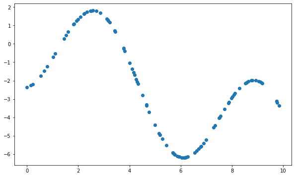

```python
# c) Do prediction
x_test = np.random.uniform(0, 10, 100)
X_test = np.column_stack([np.repeat(1, 100), x_test, np.cos(x_test), np.sin(x_test)])
yhat = X_test@beta
plt.plot(x_test, yhat, 'o')
plt.show()
```

## (d)

Do a least squares fit by instead using the `linear_model()` function in `Python`. Check that you get the same estimates as in (b).

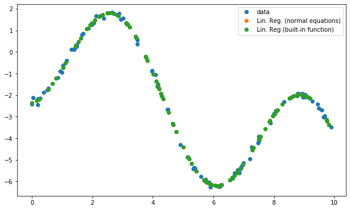

```python
# d) Linear regression
model = skl_lm.LinearRegression()
model.fit(X_train, y_train)
prediction = model.predict(X_test)

plt.plot(x_train, y_train, 'o', label='data')
plt.plot(x_test, yhat, 'o', label = 'Lin. Reg. (normal equations)')
plt.plot(x_test, prediction, 'o', label='Lin. Reg (built-in function)')

plt.legend()
plt.show()
```

# 2.5 Regularization

In this exercise we will apply Ridge regression and Lasso for fitting a polynomial to a scalar data set. We will have a setting where we first generate synthetic training data from

$$y = x^3 + 2x^2 + 6 + \epsilon, \qquad (2.2)$$

and later try to learn model for the data.

## (a)

Write a function that implements the polynomial (2.2), i.e., takes $x$ as argument and returns $x^3 + 2x^2 + 6$.

```python
# a)
def f(x):
    return x**3 + 2*x**2 + 6
```

## (b)

Use `np.random.seed()` to set the random seed. Use the function `np.linspace()` to construct a vector `x` with `n = 12` elements equally spaced from $-2.3$ to $1$. Then use your function from (a) to construct a vector $\textbf{y} = [y_1, ..., y_n]^T$ with 12 elements, where $y = x^3 + 2x^2 + 6 + \epsilon$, with $\epsilon \sim \mathcal{N(0, 1^2)}$. This is our training data.

```python
# b)
np.random.seed(0)
x_train = np.linspace(-2.3, 1, 12)
y_train = f(x_train) + np.random.normal(0, 1, 12)
```

## (c)

Plot the training data $\mathcal{T} = \{x_i, y_i\}_{i=1}^{12}$ together with the "true" function.

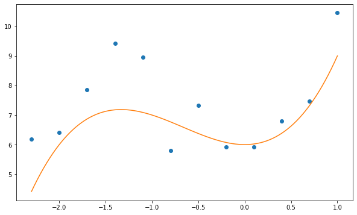

```python
# c)
x_test = np.linspace(-2.3, 1, 100)
y_test = f(x_test)

plt.plot(x_train, y_train, 'o')
plt.plot(x_test, y_test)
plt.show()
```

## (d)

Fit a straight line to the data with $y$ as output and $x$ as input and plot the predicted output $\hat{y}_{\star}$ for densely spaced $x_{\star}$ values between $-2.3$ and $1$. Plot these predictions in the same plot window.

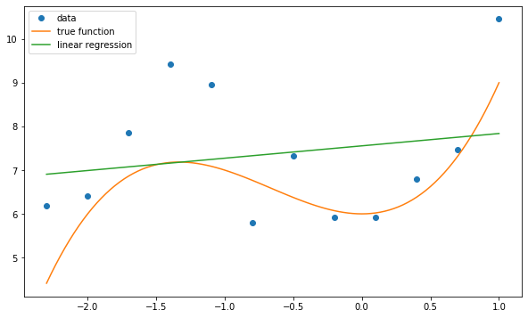

```python
# d)
# Linear regression
model = skl_lm.LinearRegression()
model.fit(x_train.reshape(-1,1), y_train)
prediction = model.predict(x_test.reshape(-1,1))

# Plots
plt.plot(x_train, y_train, 'o', label='data')
plt.plot(x_test, y_test, label='true function')
plt.plot(x_test, prediction, label='linear regression')

plt.legend()
plt.show()
```

## (e)

Fit a 11th degree polynomial to the data with linear regression. Plot the corresponding predictions.

```python
# e)
# Add X^n, n=1, 2...11, to x_train and x_test
x_train_ext = x_train.reshape(-1,1)
x_test_ext = x_test.reshape(-1,1)

for i in range(10):
    x_train_ext = np.column_stack([x_train_ext,x_train.reshape(-1,1)**(i+2)])
    x_test_ext = np.column_stack([x_test_ext,x_test.reshape(-1,1)**(i+2)])

# verify
print(x_train_ext[0,:])
print(x_test_ext[0,:])
```

```
[-2.30000000e+00  5.29000000e+00 -1.21670000e+01  2.79841000e+01
 -6.43634300e+01  1.48035889e+02 -3.40482545e+02  7.83109853e+02
 -1.80115266e+03  4.14265112e+03 -9.52809758e+03]
[-2.30000000e+00  5.29000000e+00 -1.21670000e+01  2.79841000e+01
 -6.43634300e+01  1.48035889e+02 -3.40482545e+02  7.83109853e+02
 -1.80115266e+03  4.14265112e+03 -9.52809758e+03]
```

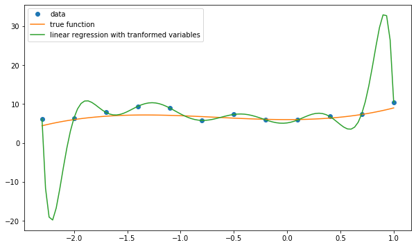

```python
model = skl_lm.LinearRegression()
model.fit(x_train_ext, y_train)
prediction = model.predict(x_test_ext)
# Plots
plt.plot(x_train, y_train, 'o', label='data')
plt.plot(x_test, y_test, label='true function')
plt.plot(x_test, prediction, label='linear regression with tranformed variables')

plt.legend()
plt.show()
```

## (f)

Use the fucntion `sklearn.linear_model.Ridge` and `sklearn.linear_model.Lasso` to fit a 11th degree polynomial. Also inspect the estimated coefficients. Try different values of penalty term $\alpha$. What do you observe?

```
Model coefficients:
[ 0.24047501  0.75707966 -0.0506247   0.79748062 -0.04197945  0.50957368
  0.38463181  0.01286643  0.5637765   0.47223915  0.0970541 ]
```

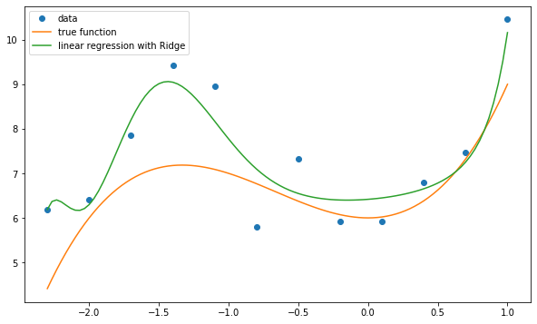

```python
# f)
# With Ridge
model = skl_lm.Ridge(alpha=1)
model.fit(x_train_ext, y_train)
print('Model coefficients: ')
print(model.coef_)

prediction = model.predict(x_test_ext)

# Plots
plt.plot(x_train, y_train, 'o', label='data')
plt.plot(x_test, y_test, label='true function')
plt.plot(x_test, prediction, label='linear regression with Ridge')

plt.legend()
plt.show()
```

```
Model coefficients:
[ 1.75687912e-01  2.20069018e+00  0.00000000e+00  1.99502387e-01
  4.20853300e-01  0.00000000e+00  1.85824779e-02  3.57481443e-03
 -1.73710840e-03  1.49116638e-03 -4.59040376e-04]
```

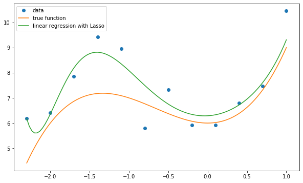

```python
# With Lasso
model = skl_lm.Lasso(alpha=0.1)
model.fit(x_train_ext, y_train)
print('Model coefficients: ')
print(model.coef_)

prediction = model.predict(x_test_ext)

# Plots
plt.plot(x_train, y_train, 'o', label='data')
plt.plot(x_test, y_test, label='true function')
plt.plot(x_test, prediction, label='linear regression with Lasso')

plt.legend()
plt.show()
```